# Prostate Cancer Machine Learning

# Exploratory Data Analysis

The file "prostate.csv" contains data from a 1989 scientific [study](https://pubmed.ncbi.nlm.nih.gov/2468795/) on prostate cancer. The data includes 8 predictors and the outcome of interest is lpsa (log prostate specific antigen).

### Load the data.

```python
import numpy as np
import pandas as pd
from sklearn import linear_model, metrics, model_selection
from sklearn.linear_model import ElasticNet
import matplotlib.pyplot as plt
from sklearn.linear_model import Ridge
import seaborn as sns
```

```python
prostate = pd.read_csv('prostate.csv')
prostate.head()
```

|  | id | lcavol | lweight | age | lbph | svi | lcp | gleason | pgg45 | lpsa |
| --- | --- | --- | --- | --- | --- | --- | --- | --- | --- | --- |
| 0 | 1 | -0.579818 | 2.769459 | 50 | -1.386294 | 0 | -1.386294 | 6 | 0 | -0.430783 |
| 1 | 2 | -0.994252 | 3.319626 | 58 | -1.386294 | 0 | -1.386294 | 6 | 0 | -0.162519 |
| 2 | 3 | -0.510826 | 2.691243 | 74 | -1.386294 | 0 | -1.386294 | 7 | 20 | -0.162519 |
| 3 | 4 | -1.203973 | 3.282789 | 58 | -1.386294 | 0 | -1.386294 | 6 | 0 | -0.162519 |
| 4 | 5 | 0.751416 | 3.432373 | 62 | -1.386294 | 0 | -1.386294 | 6 | 0 | 0.371564 |

```python
def distro(data):
    nb_sample, nb_var = data.shape
    labels = list(data)
    plt.figure(figsize = (12,8))
    for i in range(nb_var):
        ax = plt.subplot(3,3, i + 1)
        data_col = data.iloc[:, i]
        data_col.hist()
        plt.title(f'{labels[i]}')
        ax.title.set_fontsize(30)
        for item in ([ax.xaxis.label, ax.yaxis.label] +
              ax.get_xticklabels() + ax.get_yticklabels()):
            item.set_fontsize(20)
    plt.tight_layout(pad=2,w_pad=2,h_pad=2)
    plt.show()
```

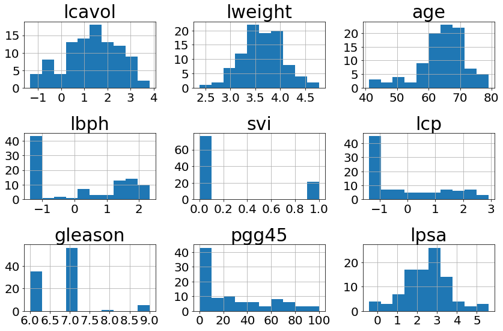

```python
distro(prostate.iloc[:,1:])
```

```python
#lpsa, the outcome variable is normally distributed
#svi is an binary, indicator variable
#lcp seems awkward. There may be measurement errors in the variable
```

### Heatmap to describe variation in the data

```python
import matplotlib.pyplot as plt
```

```
(10.0, 0.0)
```

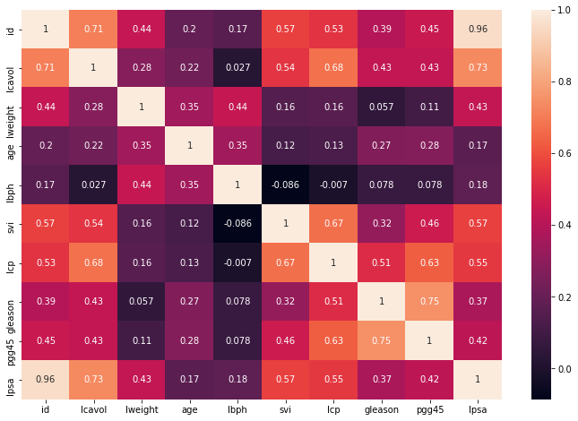

```python
fig, ax = plt.subplots(figsize=(12,8))
ax = sns.heatmap(prostate.corr(), annot = True)
bottom, top = ax.get_ylim()
ax.set_ylim(bottom + 0.5, top - 0.5)
```

### Figure to discuss variation in the data.

```python
prostate = prostate.drop(columns = ['id'])
prostate.head()
```

|  | lcavol | lweight | age | lbph | svi | lcp | gleason | pgg45 | lpsa |
| --- | --- | --- | --- | --- | --- | --- | --- | --- | --- |
| 0 | -0.579818 | 2.769459 | 50 | -1.386294 | 0 | -1.386294 | 6 | 0 | -0.430783 |
| 1 | -0.994252 | 3.319626 | 58 | -1.386294 | 0 | -1.386294 | 6 | 0 | -0.162519 |
| 2 | -0.510826 | 2.691243 | 74 | -1.386294 | 0 | -1.386294 | 7 | 20 | -0.162519 |
| 3 | -1.203973 | 3.282789 | 58 | -1.386294 | 0 | -1.386294 | 6 | 0 | -0.162519 |
| 4 | 0.751416 | 3.432373 | 62 | -1.386294 | 0 | -1.386294 | 6 | 0 | 0.371564 |

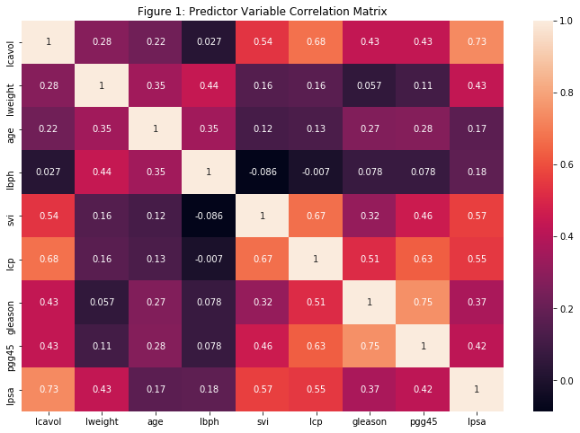

```python
fig, ax = plt.subplots(figsize=(12,8))
ax = sns.heatmap(prostate.corr(), annot = True)
bottom, top = ax.get_ylim()
ax.set_ylim(bottom + 0.5, top - 0.5)
ax.set_title('Figure 1: Predictor Variable Correlation Matrix')
```

```python
prostate.describe()
```

|  | lcavol | lweight | age | lbph | svi | lcp | gleason | pgg45 | lpsa |
| --- | --- | --- | --- | --- | --- | --- | --- | --- | --- |
| count | 97.000000 | 97.000000 | 97.000000 | 97.000000 | 97.000000 | 97.000000 | 97.000000 | 97.000000 | 97.000000 |
| mean | 1.350010 | 3.628943 | 63.865979 | 0.100356 | 0.216495 | -0.179366 | 6.752577 | 24.381443 | 2.478387 |
| std | 1.178625 | 0.428411 | 7.445117 | 1.450807 | 0.413995 | 1.398250 | 0.722134 | 28.204035 | 1.154329 |
| min | -1.347074 | 2.374906 | 41.000000 | -1.386294 | 0.000000 | -1.386294 | 6.000000 | 0.000000 | -0.430783 |
| 25% | 0.512824 | 3.375880 | 60.000000 | -1.386294 | 0.000000 | -1.386294 | 6.000000 | 0.000000 | 1.731656 |
| 50% | 1.446919 | 3.623007 | 65.000000 | 0.300105 | 0.000000 | -0.798508 | 7.000000 | 15.000000 | 2.591516 |
| 75% | 2.127041 | 3.876396 | 68.000000 | 1.558145 | 0.000000 | 1.178655 | 7.000000 | 40.000000 | 3.056357 |
| max | 3.821004 | 4.780383 | 79.000000 | 2.326302 | 1.000000 | 2.904165 | 9.000000 | 100.000000 | 5.582932 |

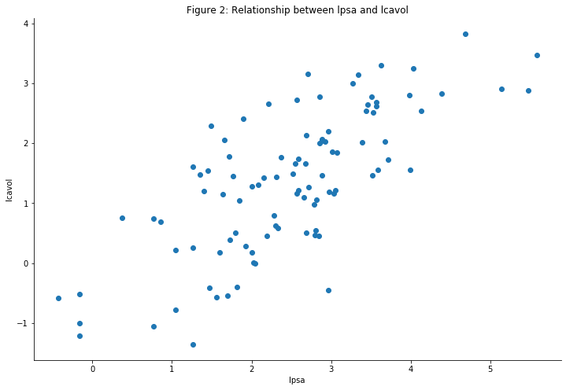

```python
#strongest correlated variable for lpsa (outcome variable) is lcavol
#plot scatterplot
fig, ax = plt.subplots(figsize=(12,8))
ax.scatter(prostate['lpsa'],prostate['lcavol'])
ax.set_xlabel('lpsa')
ax.set_ylabel('lcavol')
ax.set_title('Figure 2: Relationship between lpsa and lcavol')
ax.spines['right'].set_visible(False)
ax.spines['top'].set_visible(False)
```

# Machine Learning Using Linear Penalization Models

### Scale X Variables

```python
import sklearn.cluster
from sklearn.preprocessing import StandardScaler
```

```python
x_vars = ['lcavol','lweight','age','lbph','svi','lcp','gleason','pgg45']
X = prostate[['lcavol','lweight','age','lbph','svi','lcp','gleason','pgg45']]
scaler = StandardScaler()
scaled = scaler.fit_transform(X)
scaled = pd.DataFrame(scaled, columns = X.columns)
```

### Separate the Data into "Training" and "Testing" Samples

- Designate the testing sample to be 20% of total observations; ie, `test_size=0.2`
- Set the seed to zero; ie, `random_state=0`. This is just so we select the same testing and training samples.

```python
from sklearn.model_selection import train_test_split
X_train, X_test, y_train, y_test = train_test_split(
                                                    X,
                                                    prostate['lpsa'],
                                                    test_size=0.20,
                                                    random_state=0)
```

### Generate a Linear Prediction Model Using OLS

- Fit the model using only the training data.
- Save the coefficients.
- Generate and save the mean squared error (mse) using the training data.
- Generate and save mean squared error (mse) using the testing data.

```python
from sklearn.model_selection import cross_val_score
```

```python
ols_train = linear_model.LinearRegression().fit(X_train, y_train)
coef_ols = ols_train.coef_
coef_norm_ols = np.linalg.norm(coef_ols, ord=2)
print(coef_ols)
print('The 12 norm of the ols coefficient is {0:5.1f}.'.format(coef_norm_ols))
coef_df = pd.DataFrame({'vars':x_vars,'OLS Coefficients': coef_ols})
print(coef_df)
y_pred_train = ols_train.predict(X_train)
mse_train = np.mean((y_pred_train-y_train)**2)
y_pred_test = ols_train.predict(X_test)
mse_test = np.mean((y_pred_test-y_test)**2)
print('Training MSE:',mse_train)
print('Testing MSE:',mse_test)
```

```
[ 0.66440857  0.49688938 -0.02683145  0.11850599  0.78324749 -0.16876577
  0.13827542  0.0021738 ]
The 12 norm of the ols coefficient is   1.2.
      vars  OLS Coefficients
0   lcavol          0.664409
1  lweight          0.496889
2      age         -0.026831
3     lbph          0.118506
4      svi          0.783247
5      lcp         -0.168766
6  gleason          0.138275
7    pgg45          0.002174
Training MSE: 0.4365475217967732
Testing MSE: 0.5401691943434795
```

### Generate a Linear Prediction Model Using Ridge Regression

- Conduct cross-validation via the 'leave-one-out' approach. See [documentation](https://scikit-learn.org/stable/modules/generated/sklearn.linear_model.RidgeCV.html).
- Save the coefficients.
- Generate and save the mean squared error (mse) using the training data.
- Generate and save mean squared error (mse) using the testing data.

```python
alpha_grid = [1e-6,10,1e-2]

ridge_train = linear_model.RidgeCV(alphas=alpha_grid, store_cv_values = True).fit(X_train,y_train)
coef_ridge = ridge_train.coef_
coef_norm_ridge = np.linalg.norm(coef_ridge, ord=2)

print('The best alpha from the candidate alphas is {0}.'.format(ridge_train.alpha_))

coef_ridge_df = pd.DataFrame({'Vars':x_vars, 'Ridge Coefficients': coef_ridge})
print(coef_ridge_df)

y_pred_train_ridge = ridge_train.predict(X_train)
ridge_mse_train = np.mean((y_pred_train_ridge-y_train)**2)

y_pred_test_ridge = ridge_train.predict(X_test)
ridge_mse_test = np.mean((y_pred_test_ridge-y_test)**2)

print('Ridge Training MSE', ridge_mse_train)
print('Ridge Testing MSE:', ridge_mse_test)
```

```
The best alpha from the candidate alphas is 0.01.
      Vars  Ridge Coefficients
0   lcavol            0.664379
1  lweight            0.496531
2      age           -0.026823
3     lbph            0.118525
4      svi            0.782134
5      lcp           -0.168471
6  gleason            0.138063
7    pgg45            0.002178
Ridge Training MSE 0.4365476705696794
Ridge Testing MSE: 0.5400814088187056
```

### Generate a Linear Prediction Model Using Lasso Regression

- Fit the model using only the training data.
- See finished "linear penalization" lecture notes.
- Conduct cross-validation via the 'leave-one-out' approach. See [documentation](https://scikit-learn.org/stable/modules/generated/sklearn.linear_model.LassoCV.html).
- Save the coefficients.
- Generate and save the mean squared error (mse) using the training data.
- Generate and save mean squared error (mse) using the testing data.

```python
lasso_train = linear_model.LassoCV(cv=len(X_train)).fit(X_train,y_train)
coef_lasso = lasso_train.coef_
coef_lasso_df = pd.DataFrame({'Vars':x_vars, 'Lasso Coefficients': coef_lasso})
print(coef_lasso_df)

y_pred_train_lasso = lasso_train.predict(X_train)
lasso_mse_train = np.mean((y_pred_train_lasso-y_train)**2)

y_pred_test_lasso = lasso_train.predict(X_test)
lasso_mse_test = np.mean((y_pred_test_lasso-y_test)**2)

print('Lasso Training MSE', lasso_mse_train)
print('Lasso Testing MSE:', lasso_mse_test)
```

```
      Vars  Lasso Coefficients
0   lcavol            0.654965
1  lweight            0.417405
2      age           -0.023958
3     lbph            0.118480
4      svi            0.609598
5      lcp           -0.108863
6  gleason            0.057213
7    pgg45            0.003424
Lasso Training MSE 0.4419005952153945
Lasso Testing MSE: 0.5159025607326395
```

### Generate a Linear Prediction Model Using Elastic Net Regression

"Elastic Net" combines characteristics of both Ridge and Lasso; ie, it reduces the impact of different features while not eliminating all of the features. The Elastic Net is defined as:

$$ \begin{align*} \min_{\beta}& \Bigg\{\underbrace{\sum_{i=1}^n\big(y_i-\hat{y}_i\big)^2}_{\text{RSS}} + \lambda\times\bigg[\frac{(1-\alpha)}{2} \times\left(\sum_{j=1}^p \beta_j^2\right) + \alpha \times\sum_{j=1}^p | \beta_j|\Bigg\}\bigg] \end{align*} $$

The parameter $\alpha$ is the mixing parameter between Ridge ($\alpha=0$) and Lasso ($\alpha=1$), while $\lambda$ plays the same role as the penalty parameter. Note: the routines in `sklearn` (annoyingly) refer to $\alpha$ as the penalization paramater but convention is to use $\lambda$ as the penalization parameter.

- Fit the model using only the training data.
- Search for the best mixing parameter ($\alpha$ above) using "l1_ratio=l1_grid" ([documentation](https://scikit-learn.org/stable/modules/generated/sklearn.linear_model.ElasticNetCV.html)) where

  ```
  l1_grid = np.arange(.1,1,1e-2).tolist()
  ```

- Conduct cross-validation via the 'leave-one-out' approach. See [documentation](https://scikit-learn.org/stable/modules/generated/sklearn.linear_model.ElasticNetCV.html).
- Save the coefficients.
- Generate and save the mean squared error (mse) using the training data.
- Generate and save mean squared error (mse) using the testing data.

```python
l1_grid = np.arange(.1,1,1e-2).tolist()

elastic_train = linear_model.ElasticNetCV(l1_ratio=l1_grid, cv = len(y_train)).fit(X_train, y_train)
print('The best alpha for this model is {0:4.2f}.'.format(elastic_train.alpha_))
coef_elastic = elastic_train.coef_
coef_elastic_df = pd.DataFrame({'Vars':x_vars, 'Elastic Coefficients': coef_elastic})
print(coef_elastic_df)

y_pred_train_elastic = elastic_train.predict(X_train)
elastic_mse_train = np.mean((y_pred_train_elastic-y_train)**2)

y_pred_test_elastic = elastic_train.predict(X_test)
elastic_mse_test = np.mean((y_pred_test_elastic-y_test)**2)

print('Elastic Training MSE', elastic_mse_train)
print('Elastic Testing MSE:', elastic_mse_test)
```

```
The best alpha for this model is 0.01.
      Vars  Elastic Coefficients
0   lcavol              0.654915
1  lweight              0.417106
2      age             -0.023950
3     lbph              0.118494
4      svi              0.608736
5      lcp             -0.108622
6  gleason              0.057078
7    pgg45              0.003427
Elastic Training MSE 0.4419424054804098
Elastic Testing MSE: 0.5158699585332689
```